# Solución Tarea 4

#### Estudiantes:

- Nicolás Prieto Escobar
- Pablo A. Saldarriaga Aristizabal

### Nota: para que los plots se generen y se vean bien, es necesario ejecutar todo el notebook y tener la carpeta de github clonada en el PC local. Descargar solo el html NO generará bien los plots, ya que se usan otros html que están en un subdirectorio de donde está este notebook.

### Problema:

Se cuenta con información georeferenciada de accidentes que han ocurrido en diferentes barrios en la ciudad de Medellín durante el año 2017.

En este ejemplo, se usarán solo los datos de los accidentes que estén en los barrios de la comuna 14, El Poblado. Lo que se pretende es mostrar las ventajas que se tiene al usar una técnica de clusters basados en densidad (DBSCAN) para hallar los clusters de accidentalidad más importante de esa comuna.

Se analizará el resultado final obtenido por esta técnica y se hará un análisis de sensbilidad de algunso de sus parámetros (tipo de distancia usada, radio de las vecindades, etc).

```python
%matplotlib notebook
```

### Limpieza y preparacion de datos

```python
### Lectura de datos

### crear carpeta resultados
import os
if not os.path.exists('pruebas/'):
    os.makedirs('pruebas')

### Leer datos
import pandas as pd
datos = pd.read_csv('data/proc_accidentes_2017.csv')


### Dejar solo accidentes del Poblado
lista_poblado = """
ElGuamal
BarrioColombia
VillaCarlota
Castropol
Lalinde
LasLomasNo1
LasLomasNo2
AltosdelPoblado
ElTesoro
LosNaranjos
LosBalsosNo1
SanLucas
ElDiamanteNo2
ElCastillo
LosBalsosNo2
Alejandria
LaFlorida
ElPoblado
Manila
Astorga
PatioBonito
LaAguacatala
SantaMariadeLosÁngeles
"""
lista_poblado_l = lista_poblado.split('\n')
```

```python
## Dejar solo barrios del poblado
datos_pob = datos[datos['BARRIO'].isin(lista_poblado_l)]

### Eliminar un dato outlier raro, cuyas coordenadas quedan en san antonio de prado
datos_pob = datos_pob[datos_pob['Lon']>-75.62]


### Preparacion inicial de datos
lat = datos_pob['Lat']
lon = datos_pob['Lon']

import numpy as np
import random
random.seed(42)
```

```python
### Para que quede mejor el plot, le sumo un random pequeno
### Esto lo hago porque en la base de datos hay varias observaciones con
### exactamente la misma coordenada, esto probablemente sea una imprecision
### al etiquetar la ubicaciion del accidente, y en el mapa quedaba un punto
### encima del otro y se notaba que ahi habia varios accidentes
lats=[]
lons=[]
for i in range(len(lat)):
    lats.append(0.0005*random.random())
    lons.append(0.0005*random.random())

lat = lat + lats
lon = lon + lons

datos_pob['Lat'] = lat
datos_pob['Lon'] = lon
```

###### Funcion auxiliar para hacer los plots:

```python
############ Plotting
### Ploteo en mapa los clusters
import gmplot
def plotmap(etiqs, nombre):

    ## Creo el plot
    gmap3 = gmplot.GoogleMapPlotter(lat.mean(), lon.mean(), 14)

    colors_list = [ '#3cb44b', '#ffe119', '#4363d8', '#f58231', '#911eb4', '#46f0f0', '#f032e6', '#bcf60c', '#fabebe', '#008080', '#e6beff', '#9a6324', '#fffac8', '#800000', '#aaffc3', '#808000', '#ffd8b1', '#000075', '#ffffff','#e6194b', '#000000', '#e6194b', '#3cb44b', '#ffe119', '#4363d8', '#f58231', '#911eb4', '#46f0f0', '#f032e6', '#bcf60c', '#fabebe', '#008080', '#e6beff', '#9a6324', '#fffac8', '#800000', '#aaffc3', '#808000', '#ffd8b1', '#000075', '#808080', '#ffffff', '#000000']

    for i in range(max(etiqs)+1):
        latitude_list = np.array(lat)[np.where(np.array(etiqs)==i)]
        longitude_list = np.array(lon)[np.where(np.array(etiqs)==i)]

        # Pintar puntos de cada cluster, como circulos de cada color
        gmap3.scatter( latitude_list, longitude_list, colors_list[i],
                                      size = 8, marker = False )



    ### Pinto los que quedaron como outliers, son circulos grises
    latitude_list = np.array(lat)[np.where(np.array(etiqs)==-1)]
    longitude_list = np.array(lon)[np.where(np.array(etiqs)==-1)]
    gmap3.scatter( latitude_list, longitude_list, 'gray',
                                  size = 8, marker = False )


    ### Guardo el plot
    gmap3.draw( "pruebas/"+nombre+".html" )

    return None
```

### Clustering final obtenido con dbscan

Primero, mostraremos el resultado final obtenido al hacer clustering con dbscan, el cual obtuvimos luego de evaluar distintos metodos, hiperparametros y distancias en el modelo. Mostramos aqui este resultado para no tener que mostrar de nuevo este mapa en cada ocasion futura. Sin embargo, todos estos parametros obtenidos fueron el resultado de varias evaluaciones (luego de mostrar el mapa con el resultado final del clustering, mostraremos el analisis de sensibilidad).

```python
############ Clustering DBSCAN

### Usar dbscan para clustering
from sklearn.cluster import DBSCAN


kms_per_radian = 6371.0088  ### Para poder usar km se usa esto
distancia_en_km = 0.18   ### El radio de cada bola del metodo, en este caso es de 0.18km o 180m

epsilon = distancia_en_km / kms_per_radian  ### Esto es auxiliar, para poder usar km con las coordenadas

min_points = 20  ### Elegimos que para que un punto sea considerado denso, debe haber al menos 20 puntos en su bola
clu = DBSCAN(eps=epsilon, min_samples=min_points, metric='manhattan')  ## Usar dbscan, con metrica L1 o manhattan
clu.fit(np.radians(datos_pob[['Lat','Lon']].values))

etiqs = list(clu.labels_) ### Clusters encontrados
```

```python
### Plotear resultado clusters dbscan
plotmap(etiqs, 'map_final')


### Mostrar aqui el html
from IPython.display import IFrame
IFrame(src='pruebas/map_final.html', width=700, height=600)
```

[interactive chart not shown]

Vemos que los resultados obtenidos con dbscan son satisfactorios: se logran encontrar muchas de las agrupaciones de accidentalidad en los sitios donde el sentido común nos dice que se esperaba encontrarlas (glorieta de la aguacatala, puente Gilberto Echeverri Mejía, etc), y además notamos que el uso del clustering por densidad permite armar clusters que pueden tener distintas formas y tamaños (notar que algunas secciones como todo el parque Lleras y la 10 quedan en el mismo cluster, a pesar de ser zonas alargadas, mientras que también hay zonas pequeñas como la glorieta de la agucatala que también terminan formando un cluster).

Ademas, notar que tambien el método logra detectar que ocurren muchos accidentes en la ciudad que ocurren por simple casualidad pero no representan puntos de gran interés: estos son los puntos grises en el plot. Representarían los outliers de este modelo, son accidentes que ocurrieron pero no se asociaron exactamente a las zonas con dinámicas más comunes de accidentalidad en la zona. Notar que estos puntos están regados a través de todo el mapa, tal como se esperaba ver.

### Análisis de sensibilidad

Habiendo mostrado ya el resultado final obtenido, mostraremos entonces en esta seccion el analisis de sensibilidad relacionado. Lo que haremos ahora es entonces mostrar como diversas partes del modelo (distancia usada, hiperaparametros, etc) afectaban el resultado y asi sustentaremos porque nos quedamos con el resultado final mostrado anteriormente.

#### Ventajas de la distancia de manhattan sobre otros tipos de distancias.

En el método final, se usa la distancia de Manhattan en el DBSCAN. Aquí se analizan los resultados obtenidos por otro par de métricas para sustentar la ventaja de la métrica de manhattan sobre las demás en este caso.

```python
############ Clustering DBSCAN con distancia euclideana (L2)

### Usar dbscan para clustering
from sklearn.cluster import DBSCAN


kms_per_radian = 6371.0088  ### Para poder usar km se usa esto
distancia_en_km = 0.18   ### El radio de cada bola del metodo, en este caso es de 0.18km o 180m

epsilon = distancia_en_km / kms_per_radian  ### Esto es auxiliar, para poder usar km con las coordenadas

min_points = 20  ### Elegimos que para que un punto sea considerado denso, debe haber al menos 20 puntos en su bola
clu_l2 = DBSCAN(eps=epsilon, min_samples=min_points, metric='euclidean')  ## Usar dbscan, con metrica L2 o euclideana
clu_l2.fit(np.radians(datos_pob[['Lat','Lon']].values))

etiqs_l2 = list(clu_l2.labels_) ### Clusters encontrados
```

```python
### Plotear resultado clusters dbscan
plotmap(etiqs_l2, 'map_euclidean')


### Mostrar aqui el html
from IPython.display import IFrame
IFrame(src='pruebas/map_euclidean.html', width=700, height=600)
```

[interactive chart not shown]

Vemos que al usar la distancia euclideana, termina juntando casi todos los puntos en un mismo cluster que atraviesa practicamente toda la zona analizada.

Esto ocurre porque estamos manteniendo los distintos parametros iguales, y al usar distancia euclideana van a caber mas puntos en las vecindades que estamos formando (la distancia l1 siempre es mayor o igual a la l2). Esto ocasiona que se conecten muchas mas vecindades entre si, generando entonces un cluster gigante como el que se muestra en la imagen.

Cuando nos desplazamos en la ciudad, las calles por lo general son en forma de cuadrícula, y es por esta razón que tiene mucho más sentido medir las distancias usando la distancia de manhattan que la distancia euclideana: los carros no pueden atravesar los edificios, sino que deben seguir las vías y es en las vías donde hay accidentes.

```python
############ Clustering DBSCAN con distancia infinita (L inf)

### Usar dbscan para clustering
from sklearn.cluster import DBSCAN


kms_per_radian = 6371.0088  ### Para poder usar km se usa esto
distancia_en_km = 0.18   ### El radio de cada bola del metodo, en este caso es de 0.18km o 180m

epsilon = distancia_en_km / kms_per_radian  ### Esto es auxiliar, para poder usar km con las coordenadas

min_points = 20  ### Elegimos que para que un punto sea considerado denso, debe haber al menos 20 puntos en su bola
clu_linf = DBSCAN(eps=epsilon, min_samples=min_points, metric='chebyshev')  ## Usar dbscan, con metrica L1 o infinita
clu_linf.fit(np.radians(datos_pob[['Lat','Lon']].values))

etiqs_linf = list(clu_linf.labels_) ### Clusters encontrados
```

```python
### Plotear resultado clusters dbscan
plotmap(etiqs_linf, 'map_infinito')


### Mostrar aqui el html
from IPython.display import IFrame
IFrame(src='pruebas/map_infinito.html', width=700, height=600)
```

[interactive chart not shown]

En este caso, al usar la distancia infinito, se forma un supercluster aun más grande que el que se formaba con la distancia euclideana.

Esto ocurre porque se sabe que l1 >= l2 >= ... >= l infinito. Por esta razón, en este caso las vecindades probablemente contengan aún mas puntos cada una que con la métrica euclideana, y esto termina haciendo que las vecindades queden mucho más conectadas entre sí y se forme un cluster aún más grande.

Al igual que con la euclideana, el movimiento de los carros en la ciudad tampoco tiene sentido que sea basado en la distancia infinito. La manera más correcta de representar ese movimiento es usando al distancia de manhattan y por eso tiene sentido que con la métrica de manhattan se obtengan los mejores resultados.

#### Comparación para algunos valores del parámetro de puntos mínimos en una bola para ser considerada densa.

En este caso, comparamos que ocurre cuando ponemos un valor de puntos mínimos de una bola densa muy alto o muy bajo, evidenciando así la importancia de elegir bien dicho valor.

```python
############ Clustering DBSCAN con minimo de puntos de bola densa muy bajo

### Usar dbscan para clustering
from sklearn.cluster import DBSCAN


kms_per_radian = 6371.0088  ### Para poder usar km se usa esto
distancia_en_km = 0.18   ### El radio de cada bola del metodo, en este caso es de 0.18km o 180m

epsilon = distancia_en_km / kms_per_radian  ### Esto es auxiliar, para poder usar km con las coordenadas

min_points = 5  ### Elegimos que para que un punto sea considerado denso, debe haber al menos 5 puntos en su bola
clu_lowminpts = DBSCAN(eps=epsilon, min_samples=min_points, metric='manhattan')  ## Usar dbscan, con metrica L1 o manhattan
clu_lowminpts.fit(np.radians(datos_pob[['Lat','Lon']].values))

etiqs_lowminpts = list(clu_lowminpts.labels_) ### Clusters encontrados
```

```python
### Plotear resultado clusters dbscan
plotmap(etiqs_lowminpts, 'map_lowminpts')


### Mostrar aqui el html
from IPython.display import IFrame
IFrame(src='pruebas/map_lowminpts.html', width=700, height=600)
```

[interactive chart not shown]

En este caso, al poner que para que una bola sea densa se necesita un numero mas bajo de puntos que el que teniamos (5 en vez de 20), vemos que se forma un supercluster verde y ademas se forman muchos clusters muy pequeños en partes del mapa.

El supercluster ocurre porque como ya se requieren menos puntos para ser densa, se crean entonces muchas más bolas densas que en el caso original, esto conlleva a que haya mucha mayor posibilidad de que se conecten esos puntos entre sí y terminen formando una gran vecindad, tal como ocurrió. Además, al requerir menos puntos para que una bola sea densa, se forman clusters en sitios que antes eran considerados como outliers por no alcanzar a llegar al umbral. Esto forma clusters en sitios que quizás no sean tan importantes o relevantes como los demás.

Estas razones apoyan el hecho de que elegir un valor muy pequeño de número mínimo de puntos para que la bola sea densa no es la mejor opción.

```python
############ Clustering DBSCAN con minimo de puntos de bola densa muy alto

### Usar dbscan para clustering
from sklearn.cluster import DBSCAN


kms_per_radian = 6371.0088  ### Para poder usar km se usa esto
distancia_en_km = 0.18   ### El radio de cada bola del metodo, en este caso es de 0.18km o 180m

epsilon = distancia_en_km / kms_per_radian  ### Esto es auxiliar, para poder usar km con las coordenadas

min_points = 50  ### Elegimos que para que un punto sea considerado denso, debe haber al menos 50 puntos en su bola
clu_highminpts = DBSCAN(eps=epsilon, min_samples=min_points, metric='manhattan')  ## Usar dbscan, con metrica L1 o manhattan
clu_highminpts.fit(np.radians(datos_pob[['Lat','Lon']].values))

etiqs_highminpts = list(clu_highminpts.labels_) ### Clusters encontrados
```

```python
### Plotear resultado clusters dbscan
plotmap(etiqs_highminpts, 'map_highminpts')


### Mostrar aqui el html
from IPython.display import IFrame
IFrame(src='pruebas/map_highminpts.html', width=700, height=600)
```

[interactive chart not shown]

En este segundo caso, lo que se hizo fue aumentar el numero mínimo de puntos de de una bola para ser considerada densa de 20 a 50. Como podemos ver, el principal efecto que tuvo hacer esto fue que se crearon muchas menos zonas densas, esto desencadenó que algunas partes del mapa donde habíamos encontrado la existencia de clusters ya sean marcadas como outliers en vez de clusters debido a que, a pesar de que hubo varios accidentes ahí, su número no fue suficiente para ser considerada densa.

Este resultado no lo consideramos tan bueno como el original, debido a que se quitaron clusters de algunas zonas que se conoce que tienen alta accidentalidad en la ciudad (por ejemplo, las zonas cercanas al mall El Tesoro, las cuales son muy frecuentadas por visitantes y por ende tienen presencia de varios choques, ya son consideradas como outliers en este caso). Lo que ocurrió entonces es que al aumentar tanto el número mínimo de puntos de una bola densa, a pesar de que se conservaron los clusters de mayor tamaño, se perdieron algunos otros clusters que no eran tan grandes pero que también eran de interés.

#### Comparación para algunos valores del parámetro de radio de las bolas (vecindades).

El último análisis de sensibilidad que haremos consiste en ver que ocurre cuando variamos el radio de las vecindades del método. Veremos que pasa al poner un radio muy alto o muy bajo en este ejemplo.

```python
############ Clustering DBSCAN con radio de bola muy bajo

### Usar dbscan para clustering
from sklearn.cluster import DBSCAN


kms_per_radian = 6371.0088  ### Para poder usar km se usa esto
distancia_en_km = 0.03   ### El radio de cada bola del metodo, en este caso es de 0.03km o 30m

epsilon = distancia_en_km / kms_per_radian  ### Esto es auxiliar, para poder usar km con las coordenadas

min_points = 20  ### Elegimos que para que un punto sea considerado denso, debe haber al menos 20 puntos en su bola
clu_lowrad = DBSCAN(eps=epsilon, min_samples=min_points, metric='manhattan')  ## Usar dbscan, con metrica L1 o manhattan
clu_lowrad.fit(np.radians(datos_pob[['Lat','Lon']].values))

etiqs_lowrad = list(clu_lowrad.labels_) ### Clusters encontrados
```

```python
### Plotear resultado clusters dbscan
plotmap(etiqs_lowrad, 'map_lowrad')


### Mostrar aqui el html
from IPython.display import IFrame
IFrame(src='pruebas/map_lowrad.html', width=700, height=600)
```

[interactive chart not shown]

En este caso, evaluamos un parámetro muy bajo para el valor del radio de cada bola. Al ponerle un valor de solo 30 metros al radio de cada bola, las bolas cubren una región muy pequeña y no son capaces de cubrir nisiquiera la zona entre una calle y la otra. Como se ve en la imagen, prácticamente los únicos cluster que se muestran son los que ocurren exactamente en la misma intersección, pero el método no es capaz de agrupar en una misma bola los accidentes que ocurren en dos intersecciones consecutivas de una misma calle. Esto se muestra evidente al examinar la zona del parque Lleras: en cada intersección de la calle 10 hay varios accidentes; sin embargo, al tener un radio de bola tan bajo, los accidentes en intersecciones consecutivas no alcanzan a conectarse, conllevando así a que no pueda formarse bien el cluster de todo el parque lleras y la calle 10.

Este caso entonces muestra que el parámetro de radio de la bola no es muy adecuado: usar 30m es un valor muy bajo ya que tiene mucho más sentido considerar que las intersecciones consecutivas en una misma calle tienen relación en cuanto a la accidentalidad (la distancia entre una calle y otra suele ser casi siempre mayor a 30m). Debido a esto, el método no puede conectar varias bolas entre sí para formar clusters más grandes de accidentalidad para representar bien las zonas.

```python
############ Clustering DBSCAN con radio de bola muy alto

### Usar dbscan para clustering
from sklearn.cluster import DBSCAN


kms_per_radian = 6371.0088  ### Para poder usar km se usa esto
distancia_en_km = 0.3   ### El radio de cada bola del metodo, en este caso es de 0.3km o 300m

epsilon = distancia_en_km / kms_per_radian  ### Esto es auxiliar, para poder usar km con las coordenadas

min_points = 20  ### Elegimos que para que un punto sea considerado denso, debe haber al menos 20 puntos en su bola
clu_highrad = DBSCAN(eps=epsilon, min_samples=min_points, metric='manhattan')  ## Usar dbscan, con metrica L1 o manhattan
clu_highrad.fit(np.radians(datos_pob[['Lat','Lon']].values))

etiqs_highrad = list(clu_highrad.labels_) ### Clusters encontrados
```

```python
### Plotear resultado clusters dbscan
plotmap(etiqs_highrad, 'map_highrad')


### Mostrar aqui el html
from IPython.display import IFrame
IFrame(src='pruebas/map_highrad.html', width=700, height=600)
```

[interactive chart not shown]

En este último caso, vemos que ocurre al poner un parámetro de radio de la bola muy alto (300m en vez de 180m). Lo que ocurre entonces es que al ser tan alto este valor, casi todas las bolas densas lograrán conectarse entre sí, generando entonces un supercluster muy grande como se muestra en la figura.

Este valor no resulta tan indicado ya que se busca lograr una separación más adecuada entre las zonas de accidentalidad, aquí al usar ese valor tan alto el método no logra distinguir una zona de la otra correctamente. Sabemos que un valor de 300m resulta bastante alto ya que esto puede llegar a incluir varias calles, lo que conlleva a que todo se interconecte. En cambio, el valor original usado de 180m representaba un umbral mucho más justo, ya que con ese valor probablemente se agrupe máximo 1 o 2 intersecciones consecutivas una con la otra, lo que resulta mucho más adecuado y más razonable para poder armar los clusters.

### Validación del método y métricas

En esta sección, se presentarán métricas para validar los resultados obtenidos por el mejor clustering de dbscan propuesto según el análisis de sensibilidad. Estos resultados serán comparados contra el método de clustering de K-means con el mismo número de clusters sobre el dataset. Se usarán distintos tipos de métricas para revaluar el rendimiento de cada tipo de clustering y se analizará cuál de los dos probablemente presente un mejor rendimiento según estas métricas.

##### Metodo de clustering: DBSCAN vs Kmeans

Se muestra como hubieran quedado los clusters al usar kmeans tradicional, para comparar su rendimiento con el cluster basado en densidad de dbscan.

```python
### Clustering con Kmeans
from sklearn.cluster import KMeans

n_clusters=19 ## Este es el numero de clusters que hallo dbscan

clu_k = KMeans(n_clusters=n_clusters, random_state=1)  ## Usar kmeans
clu_k.fit(np.radians(datos_pob[['Lat','Lon']].values))

etiqs_kmeans = list(clu_k.labels_) ### Clusters encontrados con kmeans
```

```python
#### Plot con Kmeans
plotmap(etiqs_kmeans, 'map_kmeans')


### Mostrar aqui el html
from IPython.display import IFrame
IFrame(src='pruebas/map_kmeans.html', width=700, height=600)
```

[interactive chart not shown]

Podemos ver que kmeans utiliza una forma muy similar en todos sus clusters: un circulo con un centroide en alguna de las zonas. Esto no representa bien los datos ya que muchas de las zonas aqui analizadas tienen distintas formas y tamaños no es muy adecuado analizarlas con el kmeans. El ejemplo más claro de esto está en el Parque Lleras y la calle 10 (clusters que están debajo de la palabra "Lalinde"): toda esa región representa una zona muy frecuenta de la ciudad atravesad por la misma calle y toda esa calle tiene una dinámica muy similar (muchos accidentes por ser tan transitada), por esta razón es mucho más lógico agrupar todo el parque lleras y la calle 10 en un mismo cluster como lo hace dbscan que hacerlo como lo hace aquí kmeans. KMeans lo divide en dos clusters cuando no debería ser así, esto ocurre porque KMeans no es tan bueno para identificar clusters de distintas formas y tamaños, algo que sí hace mejor DBSCAN.

Otro detalle importante son los outliers: hay accidentes que ocurrieron en regiones de muy baja accidentalidad que en realidad son más producto de la casualidad que de las condiciones de esa zona. DBSCAN hacía bien esta tarea al ser capaz de poner estos accidentes casuales como outliers que no representan en realidad clusters de accidentalida (no están en zonas densas). Por otro lado, KMeans siempre asignaba todos los puntos a todos los clusters, lo que no permite usar este método para detectar cuáles accidentes de verdad ocurren en los puntos de alta accidentalidad de la zona y cuales no, dándole entonces de nuevo la ventaja a DBSCAN.

Ahora que ya se analizaron visualmente los resultados obtenidos por K-means, se puede pasar entonces a usar métricas para comparar ambos métodos de clustering.

En este dataset, no se cuenta con una "etiqueta real" de a que cluster debería pertencer cada dato: simplemente le decimos a cada método que intente encontrar clusters de la mejor forma posible, pero no tenemos forma de saber si cada punto sí quedo en una cierta clase real ya que estas no existen (no conocemos con certezas la realidad de cómo se pueden agrupar las zonas de accidentalidad del Barrio El Poblado). Por este motivo, es necesario descartar el uso de cualquier tipo de métrica de validación que use criterios externos (es decir, las que usan las etiquetas reales son descartadas). Esto elimina la posibilidad de usar varias métricas que en otros tipos de problemas podrían ser de gran utilidad: son descartadas por ejemplo las métricas de entropía, pureza y F-measure, entre otras.

No obstante, existen también métricas de validación internas (que no requieren las etiquetas reales de cada dato), y esas son las que se usan en este trabajo para validar los resultados.

A continuación, pasamos a evalaur algunas métricas para cada uno de los métodos. Las métricas se evaluarán para el clustering obtenido tanto por DBSCAN como por K-means. Adicionalmente, se evaluarán dos escenarios en DBSCAN: en el primero se considera que todo lo que marcó como outlier forma en sí un cluster, mientras que en el otro escenario se remueven todos los puntos clasificados como outliers y se conservan solo los demás puntos para evaluar la métrica.

###### Coeficiente de silueta

La primera métrica que usaremos para comparar los resultados es una de las métricas de valdiación interna más tradicionales para evaluar métodos de clustering: el coeficiente de silueta. El coeficiente de silueta contrasta la distancia media a elementos en el mismo grupo con la distancia media a elementos en otros grupos. Por ende, este coeficiente tiene en cuenta tanto el concepto de cohesión (similitud interna de objetos de un cluster) como el de separación (qué tan distantes son los objetos de un cluster de los objetos de los demás clusters). Los valores de este coeficiente están en el intervalo de los reales contenidos entre -1 y 1, donde -1 es la peor agrupación y 1 representaría la mejor agrupación (clusters densos y bien separados).

Se debe tener en cuenta que esta métrica suele obtener valores mucho más altos cuando los clusters son convexos, como los de K-means, por encima de métodos que encuentran clusters no convexos, tal como lo hace DBSCAN.

```python
#### Coeficiente de silueta
from sklearn.metrics import silhouette_score

### K means
print('Silhouette score Kmeans: '+str(silhouette_score(np.radians(datos_pob[['Lat','Lon']].values), etiqs_kmeans, metric='cityblock')))

### DBSCAN (outliers como su propio cluster)
print('Silhouette score DBSCAN (outliers como su propio cluster): '+str(silhouette_score(np.radians(datos_pob[['Lat','Lon']].values), etiqs, metric='cityblock')))


### DBSCAN (quitando outliers)
print('Silhouette score DBSCAN (quitando outliers): '+str(silhouette_score(np.radians(datos_pob[['Lat','Lon']].values)[np.where(np.array(etiqs)>=0)[0]], np.array(etiqs)[np.where(np.array(etiqs)>=0)[0]], metric='cityblock')
))
```

```
Silhouette score Kmeans: 0.502132858149081
Silhouette score DBSCAN (outliers como su propio cluster): 0.1718778655780877
Silhouette score DBSCAN (quitando outliers): 0.2794134442429077
```

Según los resultados anteriores, podemos ver que, cómo era de esperar en este métrica, el valor del coeficiente de siluera obtenido por KMeans supera ampliamente los valores obtenidos por los dos escenaros de DBSCAN. Esto era lo esperado ya que, cómo se dijo antes, este índice suele otorgarle mejores valores a métodos que hallan clusters convexos. Se aprecia también que quitar los outliers del cálculo del coeficiente ayudó a mejorar el valor de éste para DBSCAN, aunque sigue siendo superado claramente por KMeans.

###### Calinski Harabasz

En índice de Calinski Harabasz es la proporción de la suma de la dispersión entre clusters y de la dispersión interna de todos los clusters (la dispersión se define como la suma de las distancias al cuadrado). Este índice no tiene una cota superior: mientras más alto sea valor, mejor se considera que es la partición. Al igual que en el coeficiente de silueta, este índice suele presentar valores mejores cuando los clusters son de forma convexa, por lo que suele darle mejores valores a KMeans por encima de DBSCAN.

```python
#### Coeficiente de silueta
from sklearn.metrics import calinski_harabasz_score

### K means
print('Calinski Harabasz score Kmeans: '+str(calinski_harabasz_score(np.radians(datos_pob[['Lat','Lon']].values), etiqs_kmeans)))

### DBSCAN (outliers como su propio cluster)
print('Calinski Harabasz score DBSCAN (outliers como su propio cluster): '+str(calinski_harabasz_score(np.radians(datos_pob[['Lat','Lon']].values), etiqs)))


### DBSCAN (quitando outliers)
print('Calinski Harabasz score DBSCAN (quitando outliers): '+str(calinski_harabasz_score(np.radians(datos_pob[['Lat','Lon']].values)[np.where(np.array(etiqs)>=0)[0]], np.array(etiqs)[np.where(np.array(etiqs)>=0)[0]])
))
```

```
Calinski Harabasz score Kmeans: 5388.651056846635
Calinski Harabasz score DBSCAN (outliers como su propio cluster): 687.3284187521431
Calinski Harabasz score DBSCAN (quitando outliers): 1725.099541697324
```

Según los resultados anteriores, podemos ver que, cómo era de esperar en este métrica, el valor del índice obtenido por KMeans supera ampliamente los valores obtenidos por los dos escenaros de DBSCAN. Esto era de esperar debido a que, cómo se dijo antes, este índice suele otorgarle mejores valores a métodos que hallan clusters convexos. También se aprecia que quitar los outliers del cálculo de la métrica ayudó a mejorar mucho el valor de esta métrica para DBSCAN, sin embargo sigue siendo superado claramente por KMeans.

##### Davies Bouldin Index

Este índice busca medir la "similitud" promedio que existe entre los clusters, donde dicha similitud es una medida que compara la distancia entre clusters con el tamaño de los clusters. El valor mínimo de este índice es de 0. Mientras más bajo sea el valor obtenido por este índice, se considera que mejor fue la partición. Al igual que las métricas de Calinski Harabasz y el coeficiente de silueta, este índice suele presentar valores mejores cuando los clusters son de forma convexa, por lo que suele darle mejores valores a KMeans por encima de DBSCAN.

```python
#### Davies Bouldin Index
from sklearn.metrics import davies_bouldin_score

### K means
print('Davies Bouldin index Kmeans: '+str(davies_bouldin_score(np.radians(datos_pob[['Lat','Lon']].values), etiqs_kmeans)))

### DBSCAN (outliers como su propio cluster)
print('Davies Bouldin index DBSCAN (outliers como su propio cluster): '+str(davies_bouldin_score(np.radians(datos_pob[['Lat','Lon']].values), etiqs)))


### DBSCAN (quitando outliers)
print('Davies Bouldin index DBSCAN (quitando outliers): '+str(davies_bouldin_score(np.radians(datos_pob[['Lat','Lon']].values)[np.where(np.array(etiqs)>=0)[0]], np.array(etiqs)[np.where(np.array(etiqs)>=0)[0]])
))
```

```
Davies Bouldin index Kmeans: 0.7034066694614008
Davies Bouldin index DBSCAN (outliers como su propio cluster): 3.414140580500939
Davies Bouldin index DBSCAN (quitando outliers): 0.637231429871977
```

Observando los valores obtenidos en este índice para cada caso, vemos primero que claramente el método de DBSCAN considerndo los outliers como su propio clusters obtiene un valor del índice mucho peor que los otros dos escenarios (mucho más alto). Sin embargo, se observa algo interesante en los otros dos casos: a pesar de que se sabe que por lo general este índice obtiene mejores valores para los métodos convexos, en este caso el valor obtenido por el índice para el DBSCAN quitando outliers fue mejor (más bajo) que el valor obtenido por KMeans. Esto da indicios de que el DBSCAN está haciendo un muy buen trabajo al encontrar estos clusters densos presentes en el barrio.

##### DBCV

Debido al hecho de que las métricas más tradicionales (cómo las 3 que ya presentamos) suelen obtener un mejor valor para clusters convexos, vimos la necesidad de investigar qué métrices de validación interna se pueden usar para validar métodos de clustering con resultados no convexos (basados en densidad). En la búsqueda, se encontró casi todas las métricas propuestas en la literatura para evaluar clusters no convexos requerían las etiquetas reales externas (como por ejemplo la entropía o la pureza), sin embargo, nosotros no contábamos con las etiquetas reales, por lo que debimos quedarnos considerar solamente las de validación interna.

La mejor métrica de validación interna que encontramos para clusters densos es llamada "Density-Based Clustering Validation index" (DBCV), propuesta por Moulavi, Davoud, et al. en 2014. Esta métrica está especialmente diseñada para validar métodos de clustering basados en densidad, por lo que, a diferencia de las anteriores métricas que revisamos, aquí esta métrica no suele darle valores más altos a los métodos que hallan clusters convexos como KMeans.

Los valores de este índice varían entre -1 y 1, dónde 1 es la mejor partición. Se debe tener en cuenta que esta medida aún no ha sido muy estudiada para datasets dónde se encuentren muchos clusters (en el paper mencionado el máximo de clusters en los que evaluaban la métrica era de 7), lo que conlleva a que los valores hallados en este etsudio al tener tantos clusters puedan obtener valores cercanos a -1, sin embargo, lo realmente interesante más que el valor en sí obtenido por cada escenario, es cómo dicho valor se compara contra el valor obtenido de los demás escenarios.

```python
### Calcular DBCV scores (el tiempo de computo es alto para estos, a veces varias horas)
### Metrica tomada de https://github.com/christopherjenness/DBCV
from Archivos_auxiliares.DBCV import DBCV
from scipy.spatial.distance import cityblock

dbcv_kmeans = DBCV(np.radians(datos_pob[['Lat','Lon']].values), np.array(etiqs_kmeans), dist_function=cityblock)
print('DBCV para Kmeans calculado.')
dbcv_outl_prop_clus = DBCV(np.radians(datos_pob[['Lat','Lon']].values), np.array(etiqs), dist_function=cityblock)
print('DBCV para DBSCAN con outliers como su propio cluster calculado.')
dbcv_quita_outl = DBCV(np.radians(datos_pob[['Lat','Lon']].values)[np.where(np.array(etiqs)>=0)[0]], np.array(etiqs)[np.where(np.array(etiqs)>=0)[0]], dist_function=cityblock)
print('DBCV para DBSCAN quitando outliers calculado.')
```

```
DBCV para Kmeans calculado.
DBCV para DBSCAN con outliers como su propio cluster calculado.
DBCV para DBSCAN quitando outliers calculado.
```

```python
### Luego de calculados los DBCV scores, imprimir los resultados
print('DBCV score Kmeans: ' + str(dbcv_kmeans))
print('DBCV score DBSCAN (outliers como su propio cluster): ' + str(dbcv_outl_prop_clus))
print('DBCV score DBSCAN (quitando outliers): ' + str(dbcv_quita_outl))
```

```
DBCV score Kmeans: -0.5889135077600702
DBCV score DBSCAN (outliers como su propio cluster): -0.4991944941139488
DBCV score DBSCAN (quitando outliers): -0.3927061445250306
```

A partir de los resultados obtenidos por la métrica de DBCV, vemos que en este caso el modelo que mejores resultados presenta es claramente el DBSCAN quitando outliers (valor de la métrica superior a los demás). Es curioso también notar que, al considerar los outliers como su propio cluster, el valor del índice empeora pero este sigue siendo superior al valor del índice al usar KMeans. Este índice nos mostraría entonces que los algoritmos no convexos obtenidos por DBSCAN presentan una mejor partición que los de KMeans en esta métrica.

Se recuerda que los valores aparentemente muy bajos del índice (negativos y cercanos a -1) pueden deberse a la cantidad de clusters que se usan (en el paper usaban muy pocos clusters en sus datasets, no muestran pruebas con cantidades más grandes de clusters). Lo que era importante analizar era la comparación del valor del índice en los 3 escenarios, en donde se notó claramente mejores resultados para DBSCAN que para Kmeans.

##### Matriz de similitud

Para validar los resultados de la clusterización final (la presentada al inicio) obtenida por DBSCAN, ordenamos los datos con respecto al cluster en que estos quedan y luego calculamos una matriz de similitud, la cual graficamos usando un mapa de calor.

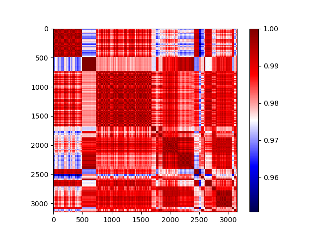

```python
### Ordenar datos segun clusters asignados
lats_t = np.array([])
long_t = np.array([])
for i in range(max(etiqs)+1):
    latitude_list = np.array(lat)[np.where(np.array(etiqs)==i)]
    longitude_list = np.array(lon)[np.where(np.array(etiqs)==i)]
    lats_t = np.concatenate((lats_t, latitude_list), axis=0)
    long_t = np.concatenate((long_t, longitude_list), axis=0)

### Juntar latitud y longitud en un dataframe
fulldat = pd.DataFrame()
fulldat['lat'] = lats_t
fulldat['lon'] = long_t

## Obtener matriz de distancias
from scipy.spatial.distance import pdist, squareform
distm = pd.DataFrame(squareform(pdist(fulldat),'cityblock'))

### Cambiarla por matriz de similitudes
simil_m = 1 - distm.values

### Pintar mapa de calor
import matplotlib.pyplot as plt
def heatmap2d(arr: np.ndarray):
    plt.figure()
    plt.imshow(arr, cmap='seismic')
    plt.colorbar()
    plt.show()
heatmap2d(simil_m)
```

Como vemos en el mapa de calor de la matriz de similitud, los cuadros de color más rojo oscuro que se forman quedan en la diagonal de esta matriz. Esto indica entonces que los datos que quedaban en un mismo cluster sí eran muy similares entre sí (los cuadros rojos oscuros de la diagonal representan los clusters). Por ende, validamos entonces que los clusters obtenidos por DBSCAN sí están siendo buenas agrupaciones para los datos.

Ahora, calculamos la matriz de similitud para DBSCAN, pero asignando los puntos outliers a su propio cluster.

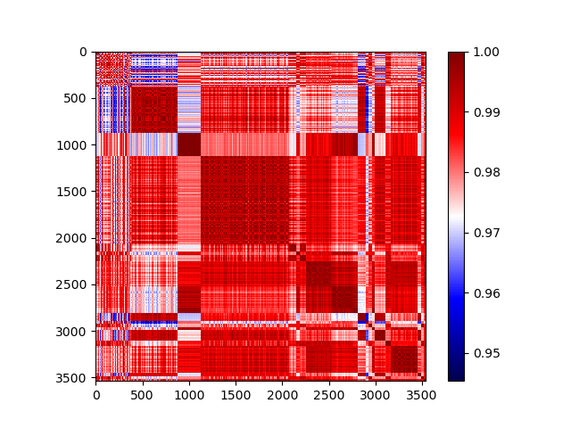

```python
### Ordenar datos segun clusters asignados
lats_t = np.array([])
long_t = np.array([])
for i in range(-1,max(etiqs)+1):
    latitude_list = np.array(lat)[np.where(np.array(etiqs)==i)]
    longitude_list = np.array(lon)[np.where(np.array(etiqs)==i)]
    lats_t = np.concatenate((lats_t, latitude_list), axis=0)
    long_t = np.concatenate((long_t, longitude_list), axis=0)

### Juntar latitud y longitud en un dataframe
fulldat = pd.DataFrame()
fulldat['lat'] = lats_t
fulldat['lon'] = long_t

## Obtener matriz de distancias
from scipy.spatial.distance import pdist, squareform
distm = pd.DataFrame(squareform(pdist(fulldat),'cityblock'))

### Cambiarla por matriz de similitudes
simil_m = 1 - distm.values

### Pintar mapa de calor
import matplotlib.pyplot as plt
def heatmap2d(arr: np.ndarray):
    plt.figure()
    plt.imshow(arr, cmap='seismic')
    plt.colorbar()
    plt.show()
heatmap2d(simil_m)
```

Por otro lado, la matriz de similitud para los datos ordenados con K-means es:

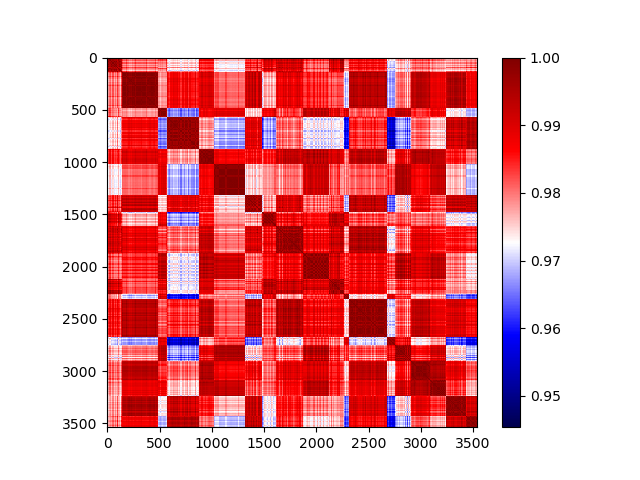

```python
### Ordenar datos segun clusters asignados
lats_t = np.array([])
long_t = np.array([])
for i in range(max(etiqs_kmeans)+1):
    latitude_list = np.array(lat)[np.where(np.array(etiqs_kmeans)==i)]
    longitude_list = np.array(lon)[np.where(np.array(etiqs_kmeans)==i)]
    lats_t = np.concatenate((lats_t, latitude_list), axis=0)
    long_t = np.concatenate((long_t, longitude_list), axis=0)

### Juntar latitud y longitud en un dataframe
fulldat = pd.DataFrame()
fulldat['lat'] = lats_t
fulldat['lon'] = long_t

## Obtener matriz de distancias
from scipy.spatial.distance import pdist, squareform
distm = pd.DataFrame(squareform(pdist(fulldat),'cityblock'))

### Cambiarla por matriz de similitudes
simil_m = 1 - distm.values

### Pintar mapa de calor
import matplotlib.pyplot as plt
def heatmap2d(arr: np.ndarray):
    plt.figure()
    plt.imshow(arr, cmap='seismic')
    plt.colorbar()
    plt.show()
heatmap2d(simil_m)
```

Los clusters de K-means también muestran que los datos agrupados en cada clusters son bastante similares. Sin embargo, se nota claramente que en este caso los clusters tienen tamaños mucho más similares entre sí. DBSCAN fue capaz de hallar clusters densos de tamaños mucho más variados, al mismo tiempo que presentaba elementos muy similares entre sí en cada uno de los clusters. Esto representaría una posible ventaja para DBSCAN: es capaz de encontrar clusters de tamaños y formas muy variadas, sin que eso disminuya lo similares que son los elementos de cada uno de sus clusters.

### Conclusión

Se concluye entonces que es muy importante escoger bien los valores de los parámetros de radio de la bola y mínimo número de puntos para ser considerada densa para obtener buenos resultados, además de elegir bien la métrica de distancia. Además, se realizó una comparación de los cluster hallados entre DBSCAN y KMeans, la cuál permitió ver lla habilidad que tiene DBSCAN de poder hallar clusters que tienen formas y tamaños distintos. Por último, se validaron los resultados de los clusters obtenidos por DBSCAN y los de Kmeans usando métricas de validación interna (coeficiente de silueta, índice de Calinski Harabasz, índice de Dabies Bouldin y DBCV), en los que se observó que en algunos de estos (sobre todo los que le dan ventaja a los convexos) era mejor Kmeans mientras que en los demás (los que estaban más diseñados para algoritmos densos como DBCV) la ventaja la tenía DBSCAN, por lo que sería interesante cómo trabajo futuro analizar el posible uso de Kmeans o de otro método de clustering para estos datos.